# Introduction to phylogenies in R

Week 4 practical — from the lecture to the keyboard

Original: Liam J. Revell · Adapted by: Moisès Coll Macià · Expanded by Viktoria Weisz

18 September 2026

# 1 How to use this document

This is an **R Markdown notebook** (`.Rmd`). It mixes three things:

1. **Text** (like this paragraph) — read it.
2. **Code chunks** — the grey boxes. This is real R code and you are meant to *run* it.
3. **Questions** — boxes marked 💭. Stop and answer them before moving on. They are the whole point of the session: the code is easy, the thinking is not.

The answers are in the **last section**, scrambled so that you cannot read them by accident. Go there first and run the one chunk you find — it takes a second and prints nothing — and you will then be able to check any answer by typing `reveal(3)` in the console.

### 1.0.1 Running code

Open this file in **RStudio**. You will see four panels:

| Panel | What it is |
| --- | --- |
| **Source** (top-left) | this document |
| **Console** (bottom-left) | where R actually runs. Code you “send” ends up here |
| **Environment** (top-right) | a list of every object you have created so far |
| **Files / Plots / Packages / Help** (bottom-right) | your folder, your figures, your help pages |

To run code:

- **One line**: put the cursor on it and press `Ctrl + Enter` (`Cmd + Enter` on Mac).
- **One whole chunk**: click the green ▶ at the top-right of the chunk, or `Ctrl + Shift + Enter`.
- **The whole document into a report**: press **Knit**. Do this *last*, not while you are exploring.

Work through the document by running chunks **in order**. Later chunks use objects created by earlier ones — if you skip ahead, R will complain that it cannot find something.

### 1.0.2 Reading output

In this document, lines that begin with `##` are *not* code — they are what R printed back at you. So this:

```r
1 + 1
```

```
## [1] 2
```

means “we asked R for `1 + 1`, and R answered `2`”. (The `[1]` is explained in §2.3.)

### 1.0.3 Getting unstuck

- `?read.tree` opens the help page for a function. Scroll to **Examples** at the bottom — usually the fastest way to understand a function.
- An error is not a disaster. Read the *first* line; it usually names the problem. §13 at the end lists the five errors you are most likely to hit today.
- Ask. You are in a room with a TA.

# 2 The R survival kit

> **Skip this section only if you have used R before.** Everything here comes back later, so 20 minutes now saves an hour of confusion at §5.

## 2.1 Objects and assignment

R is a calculator that remembers things. You store a result in an **object** with the assignment arrow `<-` (RStudio shortcut: `Alt + -`).

```r
x <- 5          # store 5 in an object called x
x               # type the name to see what is inside
```

```
## [1] 5
```

```r
x * 2           # use it
```

```
## [1] 10
```

Three things that bite beginners:

- `x <- 5` stores silently, it prints nothing. That is normal.
- R is **case-sensitive**: `x` and `X` are different objects.
- A dot `.` in a name means **nothing special** in R — it is just a character in the name. So `vert.tree` is one object called “vert.tree”, not “the tree part of vert”. (If you come from Python or Java, unlearn this now — it matters at §5 where we meet `tree$edge`.)

```r
my.first.object <- "I am just a name with dots in it"
my.first.object
```

```
## [1] "I am just a name with dots in it"
```

## 2.2 Functions and arguments

A **function** is a verb: it takes inputs (*arguments*) and gives back a result.

```r
round(3.14159, digits = 2)
```

```
## [1] 3.14
```

- `round` is the function name.
- Everything inside the `( )` are the arguments, separated by commas.
- Arguments can be given **by position** (`round(3.14159, 2)`) or **by name** (`digits = 2`). Naming is safer and self-documenting.
- Most arguments have **defaults**, so you only set the ones you want to change.

This is why phylogenetics code looks the way it does:

```r
plot(vert.tree, no.margin = TRUE, edge.width = 2)
```

is just “plot this tree, and by the way, no margins, and draw thick branches”. Nothing more mysterious than that.

> 💭 **Question 1.** `?round` tells you the function is defined as `round(x, digits = 0)`. Without running it: what will `round(2.718)` return, and why?

> *Answer: run* `reveal(1)` *(see the last section).*

```r
#reveal(1)
```

## 2.3 Vectors: R’s basic unit

R does not really do single values — it does **vectors** (an ordered sequence of values of the *same* type). Build one with `c()` (“combine”).

```r
tips <- c("cow", "pig", "whale", "bat")
tips
```

```
## [1] "cow"   "pig"   "whale" "bat"
```

```r
length(tips)
```

```
## [1] 4
```

```r
1:30
```

```
##  [1]  1  2  3  4  5  6  7  8  9 10 11 12 13 14 15 16 17 18 19 20 21 22 23 24 25
## [26] 26 27 28 29 30
```

Pick elements out with **square brackets**. R counts from **1**, not 0.

```r
tips[1]        # the first
```

```
## [1] "cow"
```

```r
tips[c(2, 4)]  # the second and the fourth
```

```
## [1] "pig" "bat"
```

```r
tips[-1]       # everything EXCEPT the first
```

```
## [1] "pig"   "whale" "bat"
```

Types matter. `"5"` (with quotes) is text; `5` is a number. R will not add text.

```r
class(tips)
```

```
## [1] "character"
```

```r
class(c(1, 2, 3))
```

```
## [1] "numeric"
```

```r
class(c(TRUE, FALSE))
```

```
## [1] "logical"
```

> 💭 **Question 2.** A tree with 82 species will have its tip names in a character vector of length 82. Write the expression that would give you the **last** tip name.. (Hint: you have `length()`.)

> *Answer: run* `reveal(2)` *(see the last section).*

```r
#reveal(2)
```

## 2.4 Lists: boxes that hold different things

A **vector** holds many values of *one* type. A **list** holds anything at all — numbers, text, matrices, even other lists — each under a name. You reach inside a list with `$`.

```r
my.list <- list(
  species = c("human", "chimp"),
  n       = 2,
  matrix  = matrix(1:4, nrow = 2)
)

my.list$species
```

```
## [1] "human" "chimp"
```

```r
my.list$n
```

```
## [1] 2
```

```r
names(my.list)   # what is in the box?
```

```
## [1] "species" "n"       "matrix"
```

**This is the single most important idea for today.** A phylogenetic tree in R *is* a list. When you write `tree$tip.label` in §5, you are just opening a labelled compartment of a box.

## 2.5 Matrices: rows and columns of numbers

```r
m <- matrix(1:6, nrow = 3)
m
```

```
##      [,1] [,2]
## [1,]    1    4
## [2,]    2    5
## [3,]    3    6
```

```r
dim(m)     # 3 rows, 2 columns
```

```
## [1] 3 2
```

```r
m[2, ]     # row 2, all columns
```

```
## [1] 2 5
```

```r
m[, 1]     # all rows, column 1
```

```
## [1] 1 2 3
```

```r
m[2, 1]    # one cell
```

```
## [1] 2
```

The comma inside `[ ]` means “rows , columns”. An empty side means “all of them”. The branches of a tree are stored exactly like this — see §5.2.

> 💭 **Question 3.** `m[2, ]` gave you a vector, not a matrix. Why do you think R drops the dimension, and when could that surprise you?

> *Answer: run* `reveal(3)` *(see the last section).*

```r
#reveal(3)
```

## 2.6 Packages: installing vs loading

R by itself does not know what a phylogeny is. That knowledge lives in **packages** written by other researchers and distributed through **CRAN** (the central R archive).

Two separate steps, and confusing them is the #1 beginner problem:

| Step | Command | How often |
| --- | --- | --- |
| **Install** — download to your hard drive | `install.packages("ape")` | **once per computer** |
| **Load** — make it available right now | `library(ape)` | **every new R session** |

If you get `could not find function "read.tree"`, you almost certainly forgot `library(ape)`.

You can also call a function without loading, using `package::function`:

```r
ape::read.tree(text = "(A,B);")
```

This is useful when two packages define a function with the same name.

## 2.7 Where am I? Files and the working directory

R always has a **working directory** — the folder it looks in when you say `read.tree(file = "anole.tre")`.

```r
getwd()
```

```
## [1] "C:/Users/weisz/Downloads"
```

**Do this now:** save this `.Rmd` file into a dedicated folder for today, and put any data files in the *same* folder. When you knit an `.Rmd`, R sets the working directory to the folder containing the `.Rmd`, so everything just works.

Windows users: if you ever type a path by hand, use forward slashes — `"C:/Users/AU/TA/anole.tre"` — or double backslashes. A single `\` is an escape character in R and will throw an error.

> 💭 **Question 4.** You run `read.tree(file = "anole.tre")` and get `Error in file(file, "r") : cannot open the connection`. Name two different things that could be wrong.

> *Answer: run* `reveal(4)` *(see the last section).*

```r
#reveal(4)
```

# 3 Installing the phylogenetics packages

R phylogenetics is built on contributed packages, and there are many. Today we need **ape**, **phangorn**, **phytools** and **geiger**.

First, check which R you are running. Packages on CRAN are built for recent R versions, so a very old R is the usual reason an install fails.

```r
R.version.string
```

```
## [1] "R version 4.5.1 (2025-06-13 ucrt)"
```

Now install. The lines below are **commented out** with `#` so that knitting this document does not reinstall everything every time. Remove the `#` from the lines you need, run them **once**, then put the `#` back.

```r
# install.packages("ape")
# install.packages("phangorn")
# install.packages("phytools")
# install.packages("geiger")
# install.packages("maps")      # needed by phytools
# install.packages("devtools")  # only if you want development versions (optional today)
```

> **MOI’s note:** installing packages sometimes triggers a prompt from RStudio asking to restart R. Say **No** — otherwise you have to load everything again.

> **MOI’s note:** if an install fails, *read the message*. It usually names a different package it could not find. Install that one first, then retry the one that failed.

**Errors vs warnings.** A **warning** (“package was built under R version …”) is R telling you something you should know; the command still worked. An **error** means nothing happened. Only errors need fixing.

Check what you have:

```r
packageVersion("ape")
```

```
## [1] '5.8.1'
```

```r
packageVersion("phangorn")
```

```
## [1] '2.12.1'
```

```r
packageVersion("phytools")
```

```
## [1] '2.5.2'
```

```r
packageVersion("geiger")
```

```
## [1] '2.0.11'
```

You want these versions or newer. `install.packages()` also pulls in every package your target depends on, which is why installing phytools takes a while — it is installing a small tree of other packages too.

Now **load** the two we will use throughout:

```r
library(ape)       # Analysis of Phylogenetics and Evolution
library(phytools)  # Liam Revell's tools, built on top of ape
```

`ape` is the foundation: almost every phylogenetics package in R reads and writes *ape*’s tree format. Learn `ape`, and the rest of the ecosystem opens up.

# 4 From text to tree: the Newick format

In the lecture, a tree was a picture. On a computer, a tree has to be **text**. The standard is the **Newick format**, and it is simply nested parentheses.

Read it like this:

- **Names** are tips (species, sequences, OTUs).
- **A pair of parentheses** groups whatever is inside it — that group shares a common ancestor not shared with anything outside the parentheses. Parentheses = a node.
- **Commas** separate the things joined at that node.
- **A semicolon** ends the tree. (Forget it, and R will hang waiting for more input.)

So `(A,B)` means “A and B are each other’s closest relatives here”, and `((A,B),C)` means “A and B join first; *then* that pair joins C”.

```r
## a 'toy' vertebrate tree, written as one long Newick string
text.string <-
  "(((((((cow, pig),whale),(bat,(lemur,human))),(robin,iguana)),coelacanth),gold_fish),shark);"

vert.tree <- read.tree(text = text.string)
```

Note the argument `text =`. `read.tree()` can take either `text =` (a string you typed) or `file =` (a file on disk). Same function, two doors in.

> 💭 **Question 5.** Before plotting: according to that string, is **whale** more closely related to **cow** or to **bat**? Trace the parentheses.

> *Answer: run* `reveal(5)` *(see the last section).*

```r
#reveal(5)
```

## 4.1 Three ways to draw the same tree

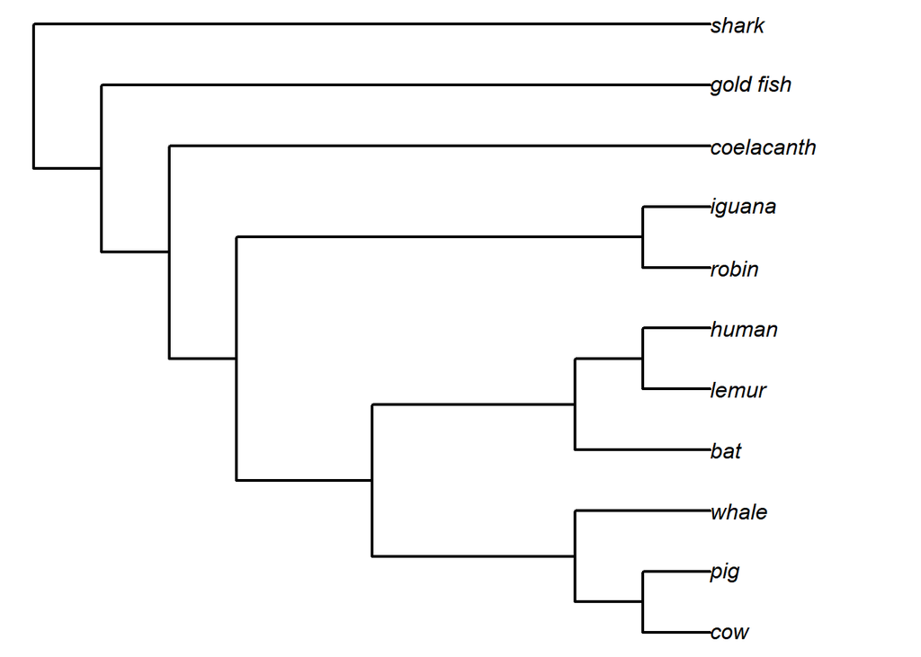

```r
plot(vert.tree, no.margin = TRUE, edge.width = 2)
```

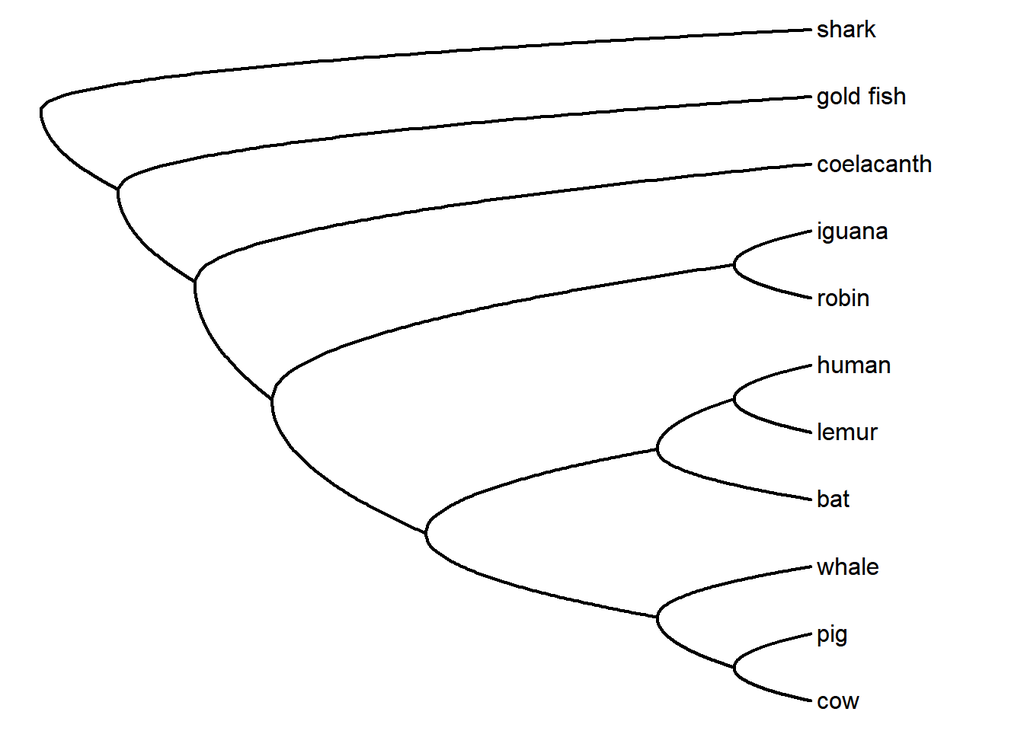

```r
roundPhylogram(vert.tree)
```

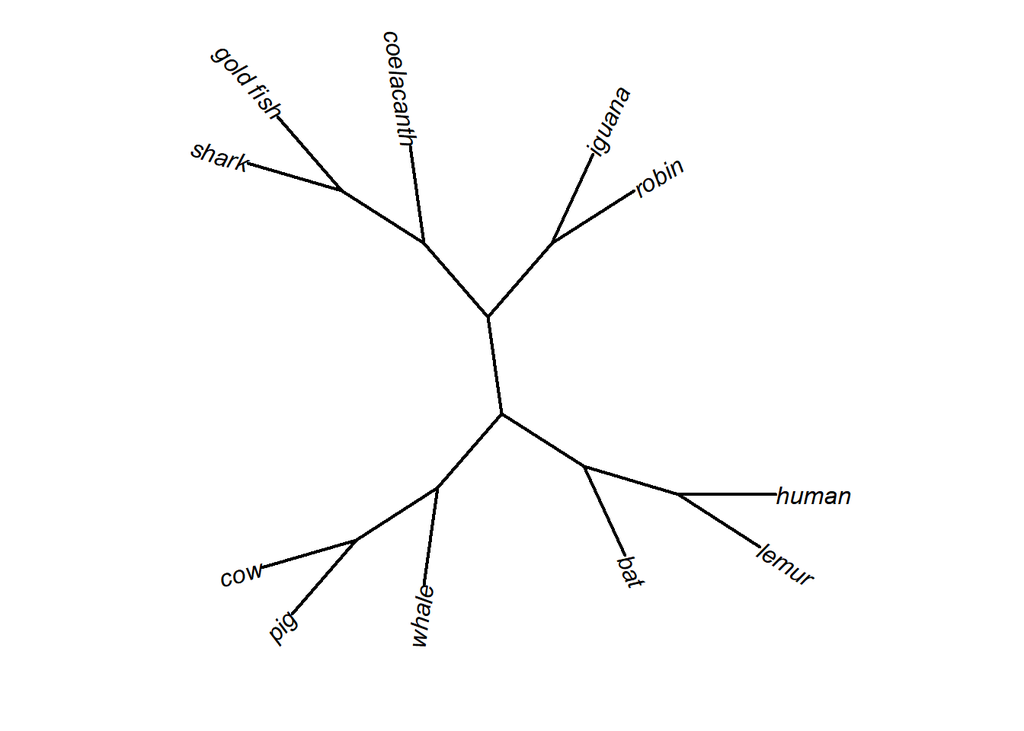

```r
plot(unroot(vert.tree), type = "unrooted", no.margin = TRUE,
     lab4ut = "axial", edge.width = 2)
```

Three pictures, and — for the first two — **one tree**. The style is cosmetic: `no.margin`, `edge.width`, `lab4ut` (“labels for unrooted tree”) only change ink.

The third plot is different in kind, and this is the part that connects straight back to the lecture. `unroot()` **removes the root**. An unrooted tree still says who groups with whom, but it no longer says *which direction time runs*, so it no longer identifies ancestors and descendants, and “clade” stops being meaningful.

This is exactly why the lecture counted **unrooted** topologies when it talked about exhaustive and branch-and-bound searches: parsimony and likelihood scores are computed on unrooted trees. Rooting is a separate step, done afterwards — usually with an **outgroup** (see §9.4).

> 💭 **Question 7.** Count the tips in the unrooted plot and in the rooted plot. Same number. Now count the **internal nodes** in each. Why is there one fewer in the unrooted version?

> *Answer: run* `reveal(7)` *(see the last section).*

# 5 Inside the `"phylo"` object

## 5.1 A tree is a list

Everything in R is an object with a **class**, and the class tells other functions how to treat it. A tree read by `ape` is a **list** (§2.4) carrying the class label `"phylo"`.

Type its name and you do *not* get the raw contents:

```r
vert.tree
```

```
##
## Phylogenetic tree with 11 tips and 10 internal nodes.
##
## Tip labels:
##   cow, pig, whale, bat, lemur, human, ...
##
## Rooted; no branch length.
```

What you see is a **summary**, produced by something called an S3 `print` method: R noticed the class was `"phylo"` and called `print.phylo()` instead of dumping the list. The same machinery is why `plot(vert.tree)` draws a phylogeny rather than a scatterplot — `plot()` looks at the class and dispatches to `plot.phylo()` from `ape`.

To see what is really in the box, use `str()` (short for *structure*):

```r
str(vert.tree)
```

```
## List of 3
##  $ edge     : int [1:20, 1:2] 12 13 14 15 16 17 18 18 17 16 ...
##  $ Nnode    : int 10
##  $ tip.label: chr [1:11] "cow" "pig" "whale" "bat" ...
##  - attr(*, "class")= chr "phylo"
##  - attr(*, "order")= chr "cladewise"
```

Read that as: a list of 3 compartments — `edge`, `Nnode`, `tip.label` — plus two attributes, `class` and `order`.

## 5.2 Decomposing a small tree

Big trees are hard to inspect. Let’s take a 5-tip tree apart.

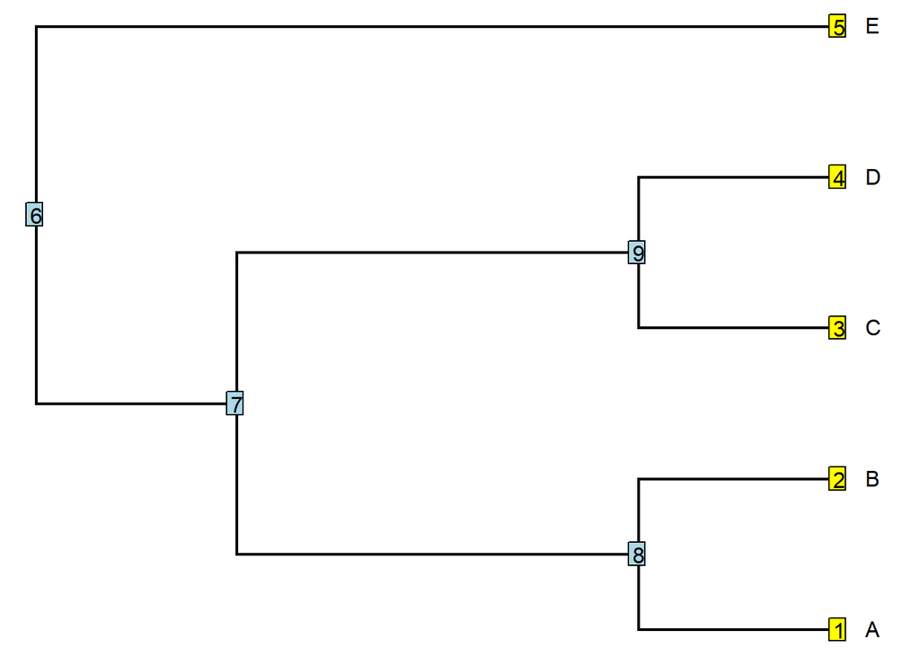

```r
tree <- read.tree(text = "(((A,B),(C,D)),E);")
plotTree(tree, offset = 1)
tiplabels()
nodelabels()
```

`tiplabels()` and `nodelabels()` print the **node numbers** onto the plot you just drew. (They add to the *current* plot, so they must be run right after `plotTree()`, in the same chunk — this is R’s old “base graphics” way of working: draw, then add on top.)

Look at the numbering convention:

- **1 … N** are the **tips**, in the order they appear in `tip.label`.
- **N+1** is always the **root**.
- **N+2 …** are the remaining internal nodes.

Now the `edge` matrix makes sense. Each **row is one branch**; column 1 is the node the branch starts at (towards the root), column 2 is the node it ends at (towards the tips).

```r
tree$edge
```

```
##      [,1] [,2]
## [1,]    6    7
## [2,]    7    8
## [3,]    8    1
## [4,]    8    2
## [5,]    7    9
## [6,]    9    3
## [7,]    9    4
## [8,]    6    5
```

```r
nrow(tree$edge)   # number of branches
```

```
## [1] 8
```

```r
tree$tip.label    # the names, in node-number order
```

```
## [1] "A" "B" "C" "D" "E"
```

```r
tree$Nnode        # number of internal nodes
```

```
## [1] 4
```

```r
class(tree)       # the label that makes plot() draw a tree
```

```
## [1] "phylo"
```

So: `edge` is the **topology**, `tip.label` maps numbers to names, `Nnode` counts the internal nodes. Everything else is optional.

> 💭 **Question 8.** In `tree$edge`, find the row(s) that describe branches ending in a tip. How can you spot them without looking at the plot?

> *Answer: run* `reveal(8)` *(see the last section).*

> 💭 **Question 9.** This tree has 5 tips and 8 branches. A rooted, fully bifurcating tree with *n* tips always has how many branches? Check your formula against `vert.tree` (11 tips, 20 branches).

> *Answer: run* `reveal(9)` *(see the last section).*

## 5.3 Branch lengths are optional

Notice what the summary said about `vert.tree`: *“Rooted; no branch lengths.”*

```r
is.null(vert.tree$edge.length)
```

```
## [1] TRUE
```

A `"phylo"` object **may** carry a fourth compartment, `edge.length` — a numeric vector, one value per row of `edge`. Without it you have a **cladogram**: branching order only. With it you have a **phylogram**: branching order *plus* an amount of evolution on each branch.

This is the same distinction the lecture drew between the **topology** and the **branch lengths** as two separate things that a method estimates. A parsimony search returns a topology and a step count; a likelihood or distance method returns a topology *and* branch lengths in units of substitutions per site. The molecular clock section of the lecture was entirely about turning those branch lengths into time — impossible on a tree that has none.

> 💭 **Question 10.** Why can you *not* test the molecular clock on `vert.tree` as it stands?

> *Answer: run* `reveal(10)` *(see the last section).*

# 6 Reading and writing trees from files

## 6.1 Reading

Real trees come from files. We will use `anole.tre`: 82 species of neotropical *Anolis* lizards.

```r
anolis.tree <- read.tree(file = "anole.tre")
anolis.tree
```

```
##
## Phylogenetic tree with 82 tips and 81 internal nodes.
##
## Tip labels:
##   Anolis_ahli, Anolis_allogus, Anolis_rubribarbus, Anolis_imias, Anolis_sagrei, Anolis_bremeri, ...
##
## Rooted; includes branch length(s).
```

Compare that summary with `vert.tree`’s: this one says **“includes branch lengths”**.

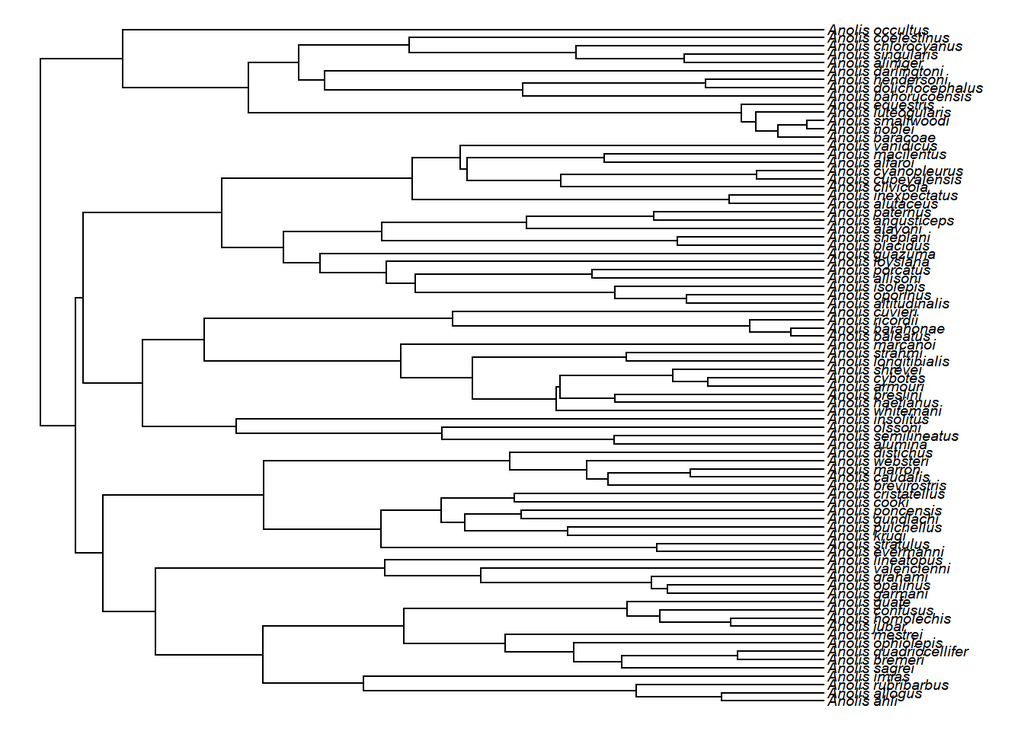

```r
plotTree(anolis.tree, ftype = "i", fsize = 0.6, lwd = 1)
```

```r
Ntip(anolis.tree)     # how many species
```

```
## [1] 82
```

```r
Nnode(anolis.tree)    # how many internal nodes
```

```
## [1] 81
```

```r
head(anolis.tree$edge.length)   # first few branch lengths
```

```
## [1] 0.2681013 0.2093223 0.4022143 0.8263459 0.7678683 2.0863429
```

`head()` shows the first few elements of anything — indispensable when an object has 162 values and you only want a glimpse.

> 💭 **Question 11.** 82 tips and 81 internal nodes. Using your rule from Question 9, is this tree fully bifurcating? What would the number have been if it contained one polytomy of three branches?

> *Answer: run* `reveal(11)` *(see the last section).*

## 6.2 Writing trees

```r
write.tree(tree, file = "example.tre")

## read the raw file back as plain text, just to look at it
cat(readLines("example.tre"), sep = "\n")
```

```
## (((A,B),(C,D)),E);
```

> **MOI’s note:** this creates a text file called `example.tre` in your folder. Open it in any text editor if you like — `cat(readLines(...))` above just prints its contents to the console.

`cat()` prints things *as they are*, without the `[1]` index or the quotes that `print()` adds. `sep = "\n"` puts each line on its own line.

> 💭 **Question 12.** `write.tree()` saved the tree perfectly. But a real analysis usually produces more than a topology — bootstrap values, posterior probabilities, a substitution model. Which of these survives a round trip through a plain Newick file?

> *Answer: run* `reveal(12)` *(see the last section).*

# 7 Plotting and manipulating trees

## 7.1 Plot styles

Same tree, different projections. First an **unrooted cladogram** — note `use.edge.length = FALSE`, which throws the branch lengths away for drawing purposes so that the topology is easier to see.

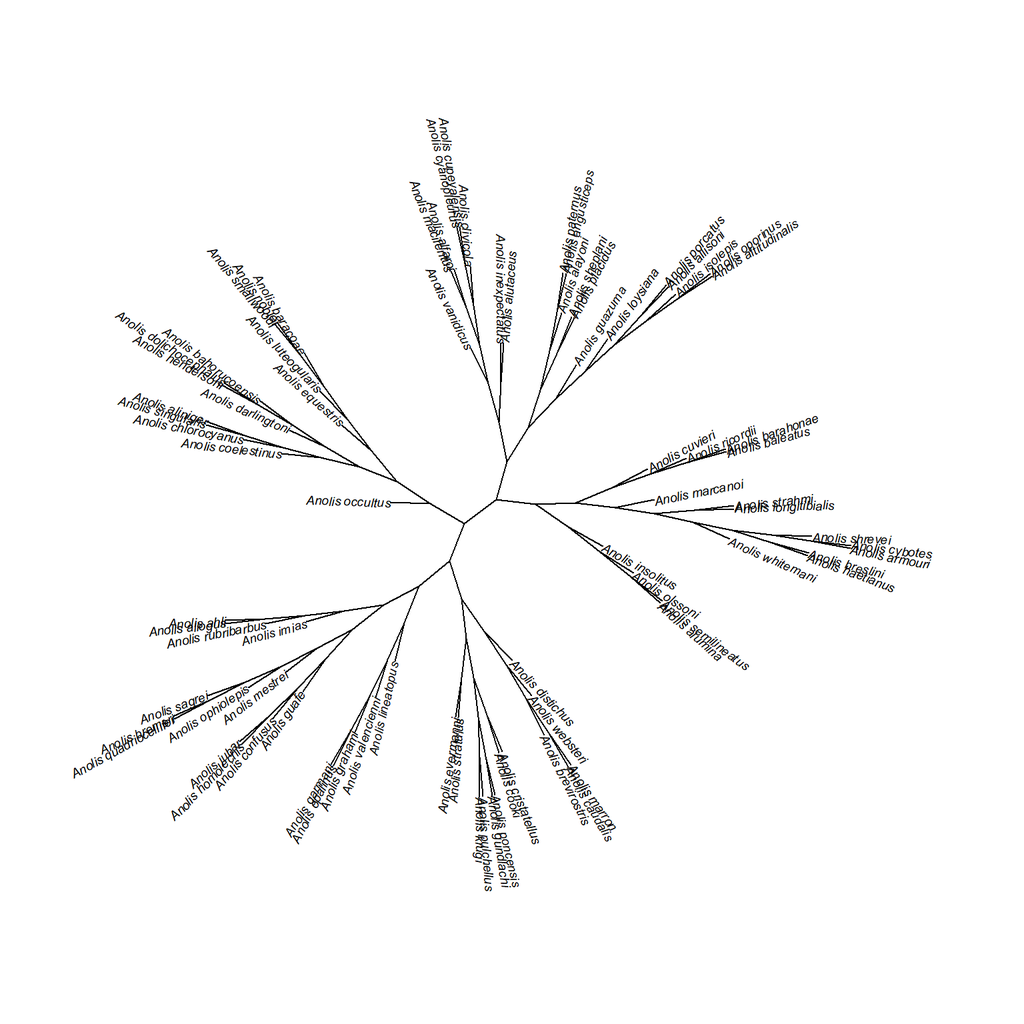

```r
plot(unroot(anolis.tree), type = "unrooted", cex = 0.6,
     use.edge.length = FALSE, lab4ut = "axial", no.margin = TRUE)
```

And a **circular (“fan”)** tree, which is the standard way to fit a large rooted tree onto one page:

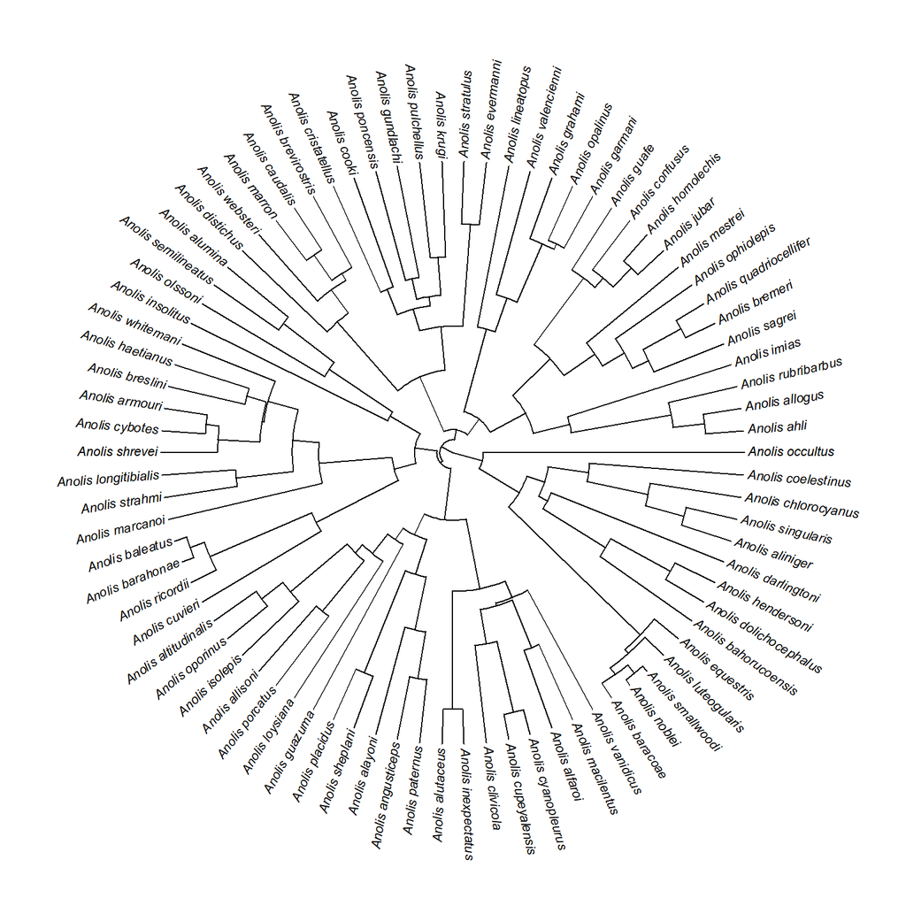

```r
plotTree(anolis.tree, type = "fan", fsize = 0.7, lwd = 1, ftype = "i")
```

> 💭 **Question 13.** `use.edge.length = FALSE` makes every branch the same length. What have you gained, and what have you just hidden from yourself?

> *Answer: run* `reveal(13)` *(see the last section).*

## 7.2 Finding particular tips

The tip labels are full names like `"Anolis_cooki"`, but we only want to type the species epithets. `grep()` searches for a pattern in a character vector and returns the *positions* where it matched.

```r
grep("cooki", anolis.tree$tip.label)   # where does "cooki" occur?
```

```
## [1] 25
```

To do that for ten species at once we use `sapply()`, which applies a function to every element of a vector and simplifies the result:

```r
pr.species <- c("cooki", "poncensis", "gundlachi", "pulchellus", "stratulus",
                "krugi", "evermanni", "occultus", "cuvieri", "cristatellus")

ii <- sapply(pr.species, grep, anolis.tree$tip.label)
ii
```

```
##        cooki    poncensis    gundlachi   pulchellus    stratulus        krugi
##           25           24           23           22           20           21
##    evermanni     occultus      cuvieri cristatellus
##           19           82           48           26
```

Read `sapply(pr.species, grep, anolis.tree$tip.label)` as: *for each* element of `pr.species`, call `grep(<that element>, anolis.tree$tip.label)`. The third argument is simply passed along to `grep`. This “apply a function to everything in a vector” pattern replaces the `for` loops you would write in most other languages.

Now turn positions back into names:

```r
pr.species <- anolis.tree$tip.label[ii]
pr.species
```

```
##  [1] "Anolis_cooki"        "Anolis_poncensis"    "Anolis_gundlachi"
##  [4] "Anolis_pulchellus"   "Anolis_stratulus"    "Anolis_krugi"
##  [7] "Anolis_evermanni"    "Anolis_occultus"     "Anolis_cuvieri"
## [10] "Anolis_cristatellus"
```

And mark them on the tree:

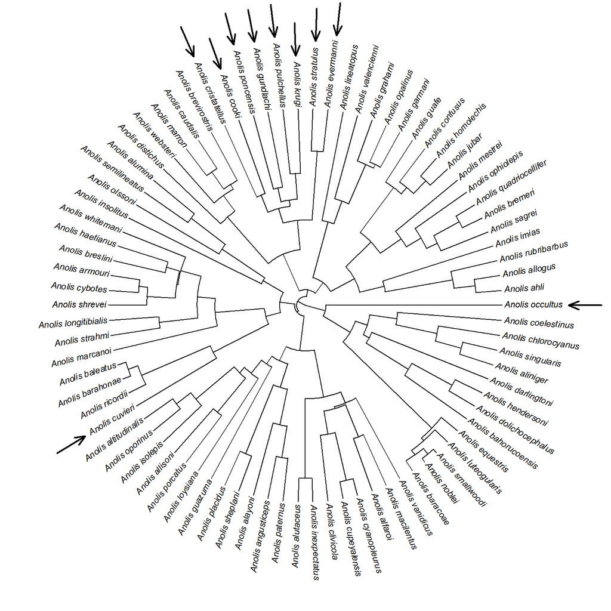

```r
plotTree(anolis.tree, type = "fan", fsize = 0.7, lwd = 1, ftype = "i")
add.arrow(anolis.tree, tip = ii, arrl = 1)
```

> 💭 **Question 14.** Look at where the arrows land. Are the Puerto Rican anoles a single clade? What would it mean, biologically, if a set of species from one island were **not** monophyletic?

> *Answer: run* `reveal(14)` *(see the last section).*

## 7.3 Dropping tips and extracting clades

`drop.tip()` removes tips and tidies up the tree that remains:

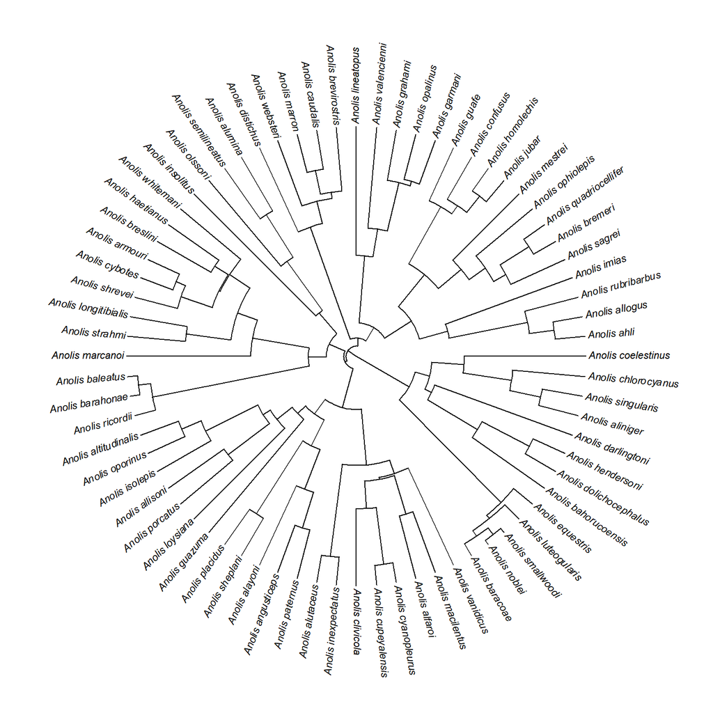

```r
anolis.noPR <- drop.tip(anolis.tree, pr.species)
plotTree(anolis.noPR, type = "fan", fsize = 0.7, lwd = 1, ftype = "i")
```

```r
Ntip(anolis.noPR)
```

```
## [1] 72
```

`fastMRCA()` finds the **most recent common ancestor** of two tips — i.e. the node where their two paths back through the tree first meet — and `extract.clade()` keeps everything descending from that node.

```r
node <- fastMRCA(anolis.tree, "Anolis_evermanni", "Anolis_cristatellus")
node
```

```
## [1] 104
```

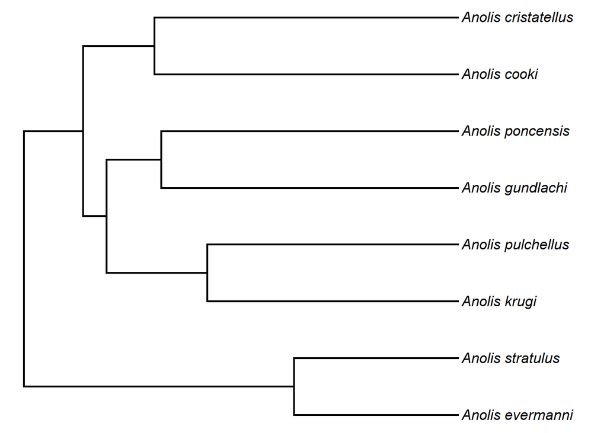

```r
pr.clade <- extract.clade(anolis.tree, node)
plotTree(pr.clade, ftype = "i")
```

Or keep the species we want by dropping everything else. `setdiff(a, b)` returns “everything in `a` that is not in `b`”:

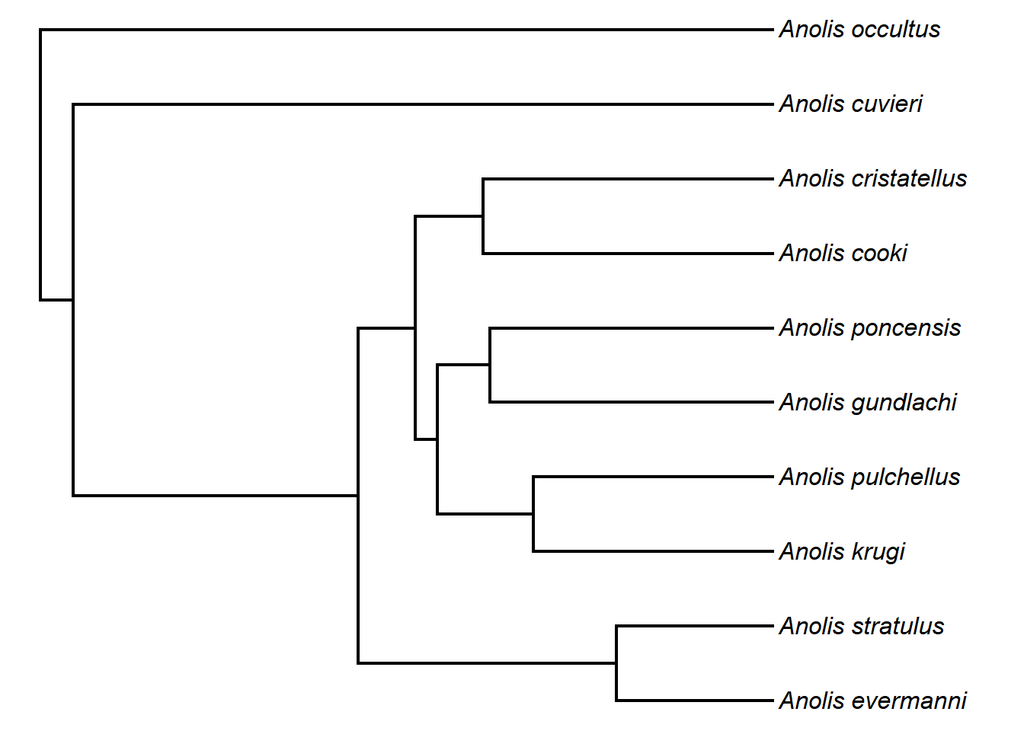

```r
pr.tree <- drop.tip(anolis.tree,
                    setdiff(anolis.tree$tip.label, pr.species))
plotTree(pr.tree, ftype = "i")
```

> **MOI’s note:** `collapseTree()` lets you prune interactively, but it must be run **in the console**, not inside a chunk. Press `ESC` to leave interactive mode.

```r
# anolis.pruned <- collapseTree(anolis.tree)
# plotTree(anolis.pruned, type = "fan", fsize = 0.7, lwd = 1, ftype = "i")
```

> 💭 **Question 15.** `pr.clade` has 8 tips; `pr.tree` has 10. Both are “the Puerto Rican anoles”. What is the difference between them, and which one would you use to ask *“how old is the Puerto Rican radiation?”*

> *Answer: run* `reveal(15)` *(see the last section).*

> 💭 **Question 16.** Does pruning change the relationships among the *remaining* species? Reason it through with the `edge` matrix in mind, then check: does `anolis.noPR` still put *Anolis_ahli* with *Anolis_allogus*?

> *Answer: run* `reveal(16)` *(see the last section).*

# 8 Binary and polytomous trees

A node with more than two descendants is a **polytomy** (or multifurcation). Most phylogenetics functions assume a **binary** (fully bifurcating) tree, so it is worth checking.

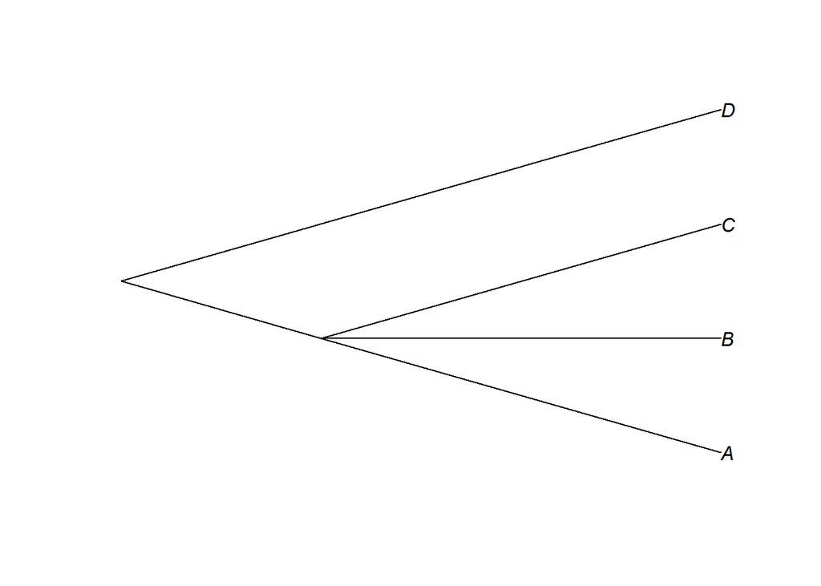

```r
t1 <- read.tree(text = "((A,B,C),D);")
plot(t1, type = "cladogram")
```

```r
is.binary(t1)
```

```
## [1] FALSE
```

> **Note on an old function name:** the original tutorial used `is.binary.tree()`. That name is deprecated in current versions of ape — use `is.binary()`. If you meet code that still calls the old name, this is why it warns.

`multi2di()` (“multifurcation to dichotomy”) resolves polytomies:

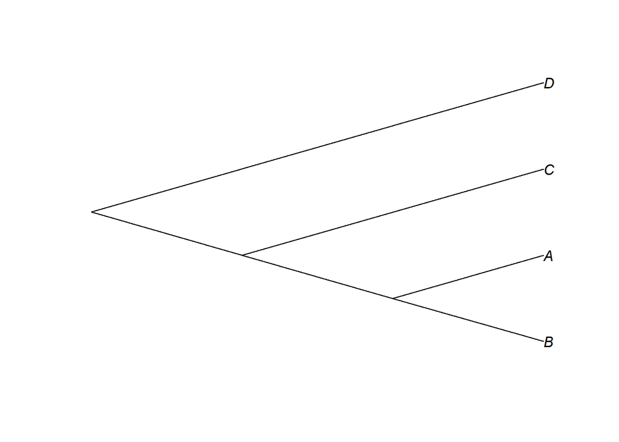

```r
t2 <- multi2di(t1)
plot(t2, type = "cladogram")
```

```r
is.binary(t2)
```

```
## [1] TRUE
```

**What does “randomly resolve” actually do?** It does not estimate anything and it uses no data. At the polytomy `(A,B,C)` there are three possible bifurcating resolutions — `((A,B),C)`, `((A,C),B)`, `((B,C),A)` — and `multi2di()` picks one at random, inserting a new internal node and a new branch of length **zero** (so the tree’s total length is unchanged). Run it several times and you will get different answers:

```r
replicate(5, write.tree(multi2di(t1)))
```

```
## [1] "(((C,B),A),D);" "(((C,A),B),D);" "(((C,A),B),D);" "(((B,C),A),D);"
## [5] "(((A,B),C),D);"
```

A zero-length branch is the honest bookkeeping: the tree is now binary in *shape*, so functions that demand a binary tree will run, but the new node carries no evidence. Treat anything that depends on that node as unsupported.

> 💭 **Question 17.** A polytomy in a published tree can mean two completely different things. What are they, and which one does `multi2di()` assume?

> *Answer: run* `reveal(17)` *(see the last section).*

# 9 Rotating and re-rooting

## 9.1 First: random trees, and `set.seed()`

```r
set.seed(1)          ## so that everyone gets the same "random" tree
tree <- rtree(n = 40)
```

> **MOI’s note:** `set.seed()` fixes a random process. R’s random numbers are not really random — they are produced by a deterministic recipe from a starting value, the *seed*. Normally R takes the seed from the clock, so every run differs. Set the seed by hand and everyone who runs the same code gets the same result, which makes a practical (or a paper) reproducible. To see it: comment out `set.seed(1)`, run the chunk several times and watch the tree change; then uncomment it and watch it stop changing.

`rtree(n = 40)` **simulates** a random 40-tip tree with random branch lengths. It is not estimated from anything — it is a convenient toy for testing code.

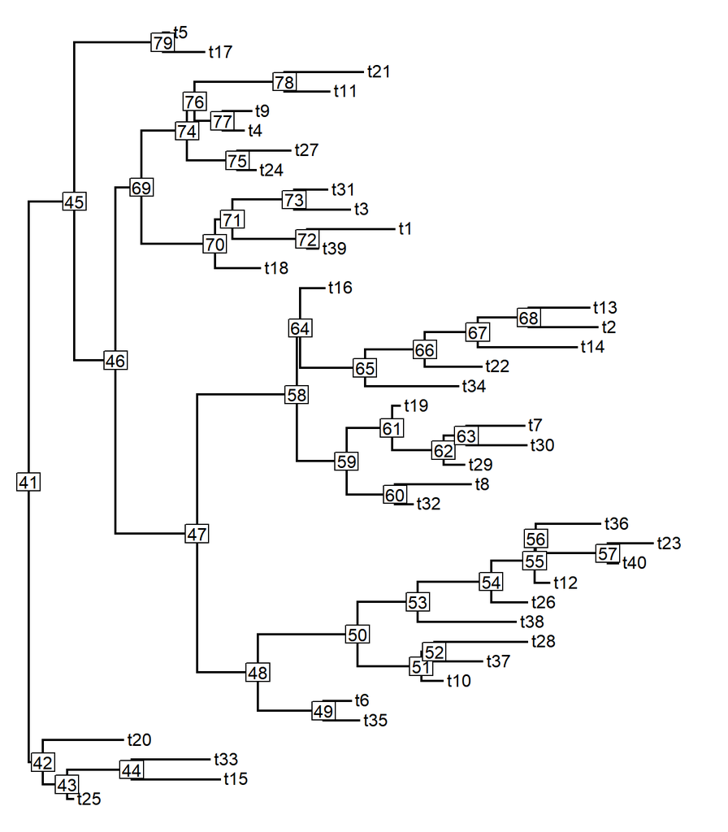

```r
plotTree(tree, node.numbers = TRUE)
```

## 9.2 Rotating: a different picture, the same tree

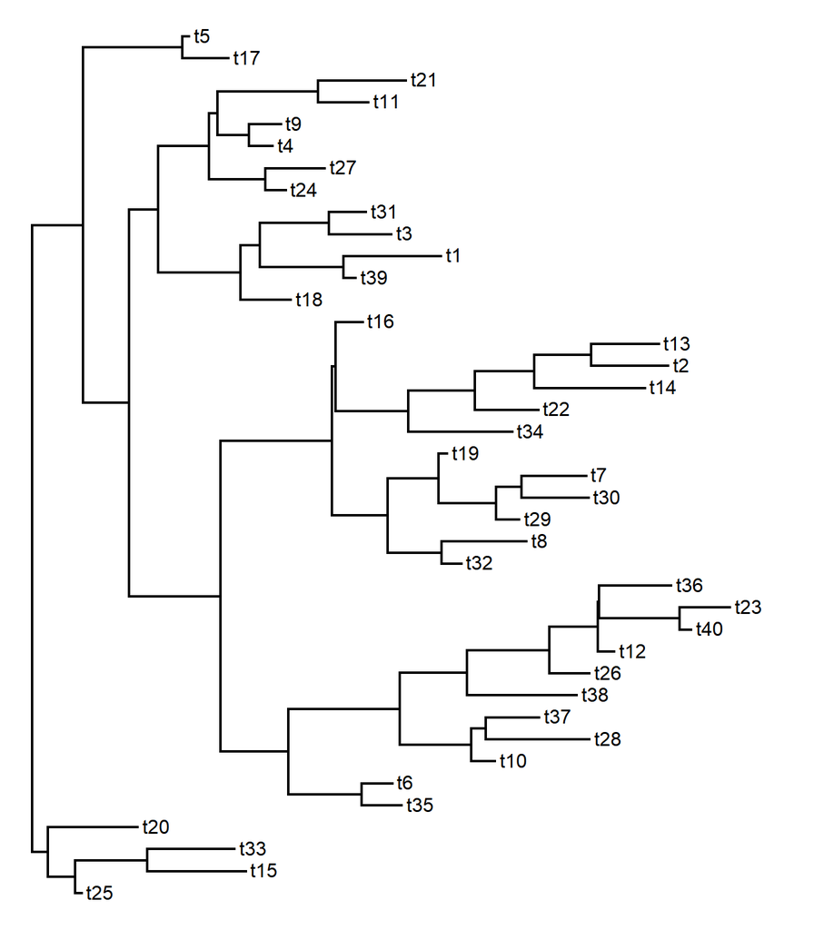

```r
rt.52 <- rotate(tree, 52)          ## rotate about node 52
plotTree(rt.52)
```

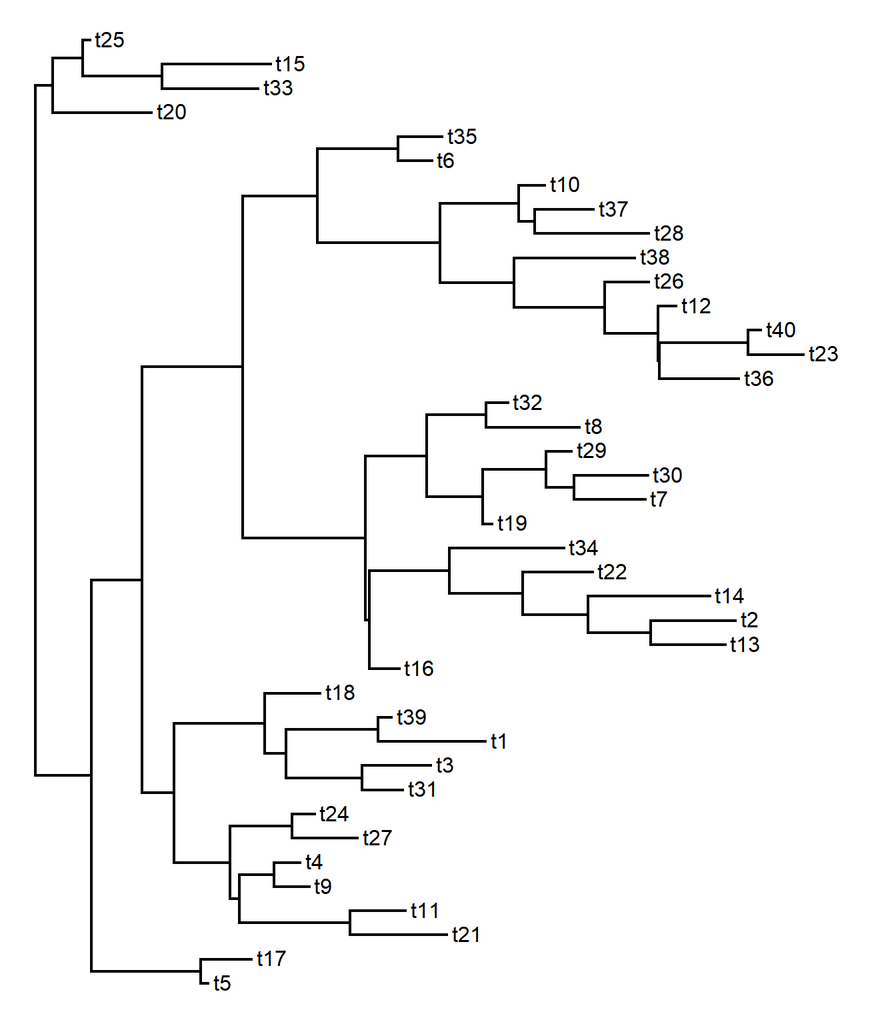

```r
rt.all <- rotateNodes(tree, "all") ## rotate every node
plotTree(rt.all)
```

Rotating swaps which descendant is drawn above and which below. Nothing about ancestry changes — only the layout.

## 9.3 Re-rooting: a genuinely different tree

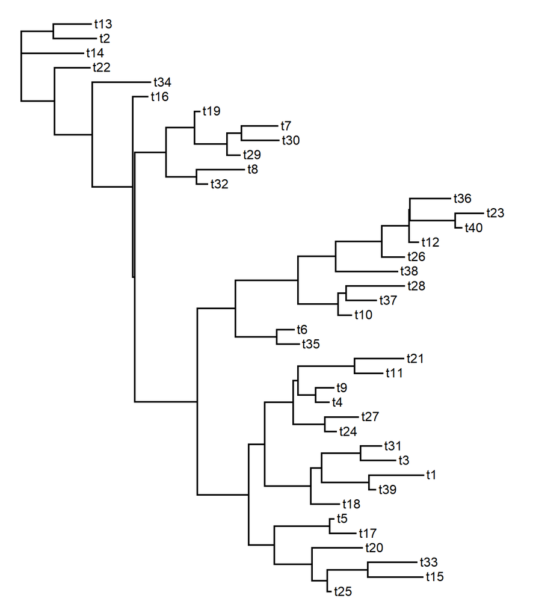

```r
rr.67 <- root(tree, node = 67)
plotTree(rr.67)
```

Rooting **at a node** creates a trifurcation at the root (the root has no branch of its own to sit on). Usually you want to root **along a branch** instead — here, exactly halfway down the branch leading to node 65:

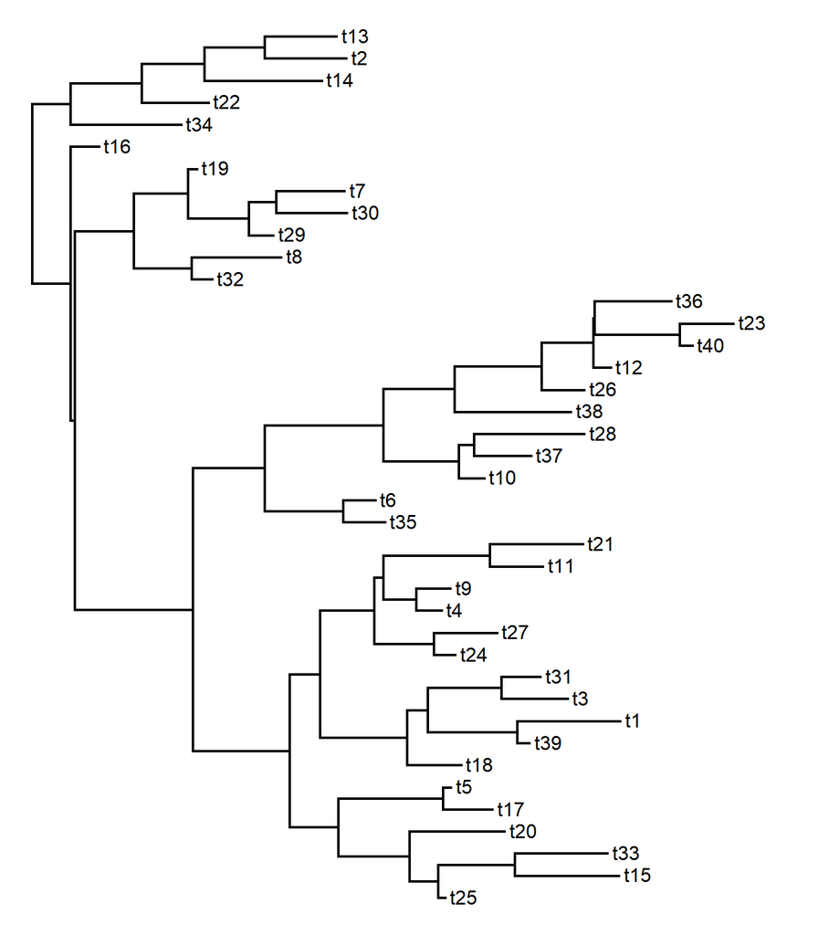

```r
rr.65 <- reroot(tree, 65,
                position = 0.5 * tree$edge.length[which(tree$edge[, 2] == 65)])
plotTree(rr.65)
```

Unpack that `position` argument, because it is a good example of R idiom:

- `tree$edge[, 2] == 65` → a TRUE/FALSE vector: is this row’s *ending* node 65?
- `which(...)` → the row number where it is TRUE.
- `tree$edge.length[...]` → the length of that branch.
- `0.5 * ...` → halfway along it.

> **MOI’s note:** interactive re-rooting must be run in the console.

```r
# rr.interactive <- reroot(tree, interactive = TRUE)
# plotTree(rr.interactive)
```

## 9.4 Why rooting is the step that matters

The lecture spent a long time on rooting — the tree of life is drawn unrooted, and finding the root of it required the EF-Tu / EF-G gene duplication as an internal outgroup. Here is the operational version of that point:

An **unrooted** tree says: *these are the groupings.* A **rooted** tree adds: *this one is the oldest split, and time flows this way.*

The second claim is the one that lets you say “X is ancestral”, “Y is a clade”, “trait Z was gained here and lost there”. None of those statements survive on an unrooted tree — and the data almost never place the root by themselves. You place it, with an **outgroup**: a taxon you already know branched off before all the others (shark for vertebrates; a lamprey for jawed fish; a distant species for a gene tree; a paralogue produced by a duplication, when nothing outside the group exists).

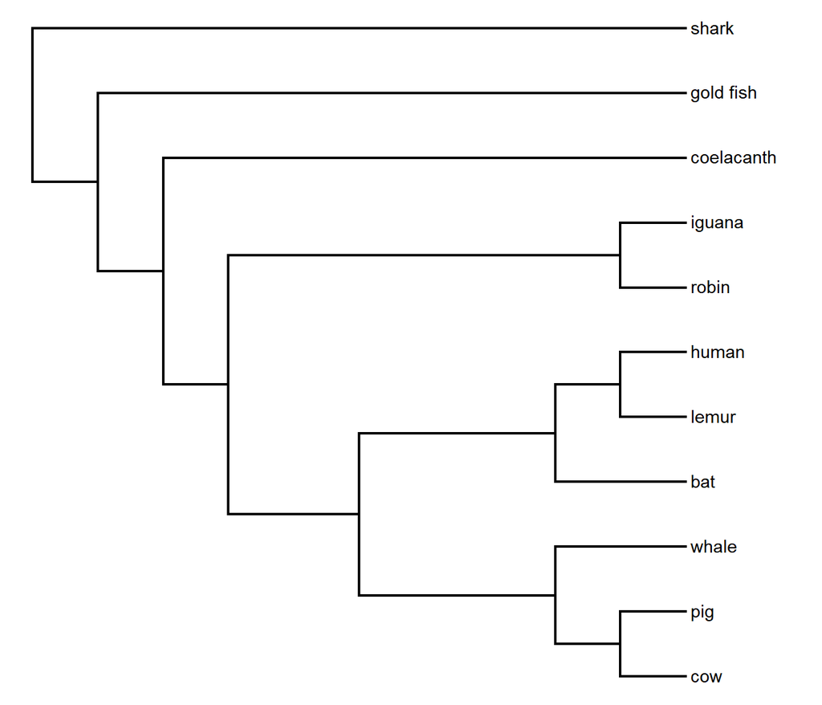

```r
## rooting a real tree with an outgroup, by name rather than node number
vt <- read.tree(text = text.string)
vt.unrooted <- unroot(vt)
vt.rerooted <- root(vt.unrooted, outgroup = "shark", resolve.root = TRUE)
plotTree(vt.rerooted, fsize = 0.9)
```

> 💭 **Question 18.** `rotate()` and `root()` both changed the picture. Which of the following statements change when you *rotate*, and which change when you *re-root*? (a) which species are sisters (b) which groups are clades (c) the order tips appear top to bottom (d) the total tree length.

> *Answer: run* `reveal(18)` *(see the last section).*

> 💭 **Question 19.** You root a gene tree with an outgroup that turns out to be *inside* your ingroup (a misidentified sequence, say). What happens to your conclusions?

> *Answer: run* `reveal(19)` *(see the last section).*

# 10 Comparing trees

Are two trees the same? `all.equal()` answers it for trees (again via the class: it dispatches to `all.equal.phylo()`).

Predict each answer **before** you run the chunk.

```r
all.equal(tree, rt.all)    ## rotated nodes
```

```
## [1] TRUE
```

```r
all.equal(tree, rr.67)     ## re-rooted
```

```
## [1] FALSE
```

```r
all.equal(unroot(tree), unroot(rr.67))  ## both unrooted
```

```
## [1] TRUE
```

Rotated trees are equal. Re-rooted trees are not — *unless* you unroot them both first, at which point the difference disappears, because rooting was the only difference.

> **A caution:** the third comparison is flagged in Liam Revell’s original tutorial as behaving inconsistently across versions. Treat `all.equal()` on unrooted trees as a check to verify, not to trust blindly.

> 💭 **Question 20.** `all.equal()` gives you TRUE or FALSE. In practice you usually want to know *how different* two trees are — a bootstrap tree vs the ML tree, a gene tree vs the species tree. Why is a yes/no answer not enough?

> *Answer: run* `reveal(20)` *(see the last section).*

## 10.1 Going further (optional): Robinson–Foulds distance

```r
library(phangorn)

RF.dist(tree, rt.all)              ## rotated: identical topology
```

```
## [1] 0
```

```r
RF.dist(unroot(tree), unroot(rr.67))
```

```
## [1] 0
```

```r
## how different is a random 40-tip tree from ours?
set.seed(42)
RF.dist(tree, rtree(n = 40, tip.label = tree$tip.label))
```

```
## [1] 74
```

RF counts the splits that the two trees do not share, so 0 means “identical topology” and the maximum for an unrooted tree with *n* tips is 2n − 6 — which is roughly what two unrelated random trees will score. It is the number you would use to say “these two gene trees conflict a lot” rather than merely “they differ”.

# 11 Multiple trees: the `"multiPhylo"` object

You very often have *many* trees rather than one: a bootstrap set, a posterior sample from a Bayesian analysis, one tree per gene, or replicate simulations. R stores these as a `"multiPhylo"` object — which is, as you might now guess, just a **list of `"phylo"` objects** wearing a different class label.

```r
anolis.trees <- c(anolis.tree, anolis.noPR, pr.clade, pr.tree)
print(anolis.trees, details = TRUE)
```

```
## 4 phylogenetic trees
## tree 1 : 82 tips
## tree 2 : 72 tips
## tree 3 : 8 tips
## tree 4 : 10 tips
```

```r
class(anolis.trees)
```

```
## [1] "multiPhylo"
```

Because it is a list, you reach individual trees with **double** brackets:

```r
anolis.trees[[3]]          ## the third tree
```

```
##
## Phylogenetic tree with 8 tips and 7 internal nodes.
##
## Tip labels:
##   Anolis_evermanni, Anolis_stratulus, Anolis_krugi, Anolis_pulchellus, Anolis_gundlachi, Anolis_poncensis, ...
##
## Rooted; includes branch length(s).
```

```r
Ntip(anolis.trees[[3]])
```

```
## [1] 8
```

```r
sapply(anolis.trees, Ntip) ## tip counts for all of them at once
```

```
## [1] 82 72  8 10
```

(`[[ ]]` gets the *contents* of a list element; `[ ]` gets a shorter list. This trips up everyone at least once.)

Many — not all — functions accept a `multiPhylo` where they accept a `phylo`:

```r
anolis.trees <- roundBranches(anolis.trees, digits = 1)   ## round all branch lengths
write.tree(anolis.trees, file = "example.trees")
```

```r
## one Newick string per line — look at just the first 120 characters of each
substr(readLines("example.trees"), 1, 120)
```

```
## [1] "((((((((Anolis_ahli:0.8,Anolis_allogus:0.8):0.7,Anolis_rubribarbus:1.4):2.1,Anolis_imias:3.5):0.8,((((Anolis_sagrei:1.5,"
## [2] "((((((((Anolis_ahli:0.8,Anolis_allogus:0.8):0.7,Anolis_rubribarbus:1.4):2.1,Anolis_imias:3.5):0.8,((((Anolis_sagrei:1.5,"
## [3] "((Anolis_evermanni:1.3,Anolis_stratulus:1.3):2.1,(((Anolis_krugi:2,Anolis_pulchellus:2):0.8,(Anolis_gundlachi:2.3,Anolis"
## [4] "((((Anolis_evermanni:1.3,Anolis_stratulus:1.3):2.1,(((Anolis_krugi:2,Anolis_pulchellus:2):0.8,(Anolis_gundlachi:2.3,Anol"
```

> 💭 **Question 21.** Your Bayesian analysis returns 10,000 trees in a `multiPhylo` object. Name two things you can compute from that set that you *cannot* get from a single tree.

> *Answer: run* `reveal(21)` *(see the last section).*

# 12 Where this fits in the lecture

[output not shown]

**You should now be able to:**

- read a Newick string by eye and say which taxa are more closely related
- explain what is inside a `"phylo"` object, and why a tree is “just a list”
- read a tree from a file and write one back
- prune tips, extract a clade, and say which of the two is monophyletic
- tell the difference between a rotated tree and a re-rooted tree, and say which claims change
- state what `multi2di()` assumes when it resolves a polytomy
- say why branch lengths, not topology, are what a molecular clock analysis needs

# 13 Troubleshooting: the five errors you will actually meet

**`could not find function "read.tree"`**

The package is not loaded. Run `library(ape)`. Installing is not loading (§2.6).

**`object 'vert.tree' not found`**

Either a typo/capitalisation difference, or you skipped the chunk that created it. Check the **Environment** panel — if it is not listed, it does not exist. Run the earlier chunks in order.

**`cannot open the connection` / `No such file or directory`**

R is not looking where you think. Run `getwd()` and `list.files()`. Put your data next to your `.Rmd`.

**`unexpected symbol` / `unexpected ')'`**

A syntax slip — a missing comma, an unclosed quote, one bracket too many. RStudio marks the line with a red 🛇 in the margin.

**The console shows `+` instead of `>` and nothing happens**

R thinks your command is unfinished (open bracket, open quote, or a Newick string missing its `;`). Press **Esc** to cancel and start again.

# 14 Answers

The answers to the 21 questions are stored in this document, but they are **scrambled**, so reading the file will not give them away. To use them:

1. Run the chunk below **once**, at the start of the session. It loads the answer key and prints nothing.
2. Whenever you want to check an answer, type `reveal(7)` in the console, using the number of the question.

Do this after you have written down your own answer. An answer you have already guessed teaches you something; an answer you read first teaches you nothing.

```r
.key <- c(
  paste0(
    "`3`. Jr qvq abg fhccyl `qvtvgf`, fb E hfrq vgf qrsnhyg, `qvtvgf = 0` - v.r. ebhaq gb n",
    " jubyr ahzore. Qrsnhygf ner vaivfvoyr va lbhe pbqr ohg nyjnlf npgvir. Guvf znggref ",
    "yngre: `cybgGerr()` unf n qbmra qrsnhygf, naq jura n cybg ybbxf bqq vg vf hfhnyyl n ",
    "qrsnhyg, abg n oht."
  ),
  paste0(
    "`gvcf[yratgu(gvcf)]`. Arfgvat shapgvbaf yvxr guvf - gur erfhyg bs bar orpbzrf gur ",
    "nethzrag bs gur arkg - vf gur fvatyr zbfg pbzzba E vqvbz. Lbh jvyy hfr vg va frpgvba 7",
    " nf `nabyvf.gerr$gvc.ynory[vv]`."
  ),
  paste0(
    "E fvzcyvsvrf n fvatyr ebj be pbyhza gb n cynva irpgbe ol qrsnhyg, orpnhfr gung vf ",
    "hfhnyyl jung lbh jnag. Vg fhecevfrf lbh jura n shapgvba rkcrpgf n gjb-pbyhza zngevk ",
    "naq lbh unir nppvqragnyyl unaqrq vg n irpgbe bs yratgu 2 - n pynffvp fbhepr bs ",
    "\"vapbeerpg ahzore bs qvzrafvbaf\" reebef. `z[2, , qebc = SNYFR]` xrrcf vg n zngevk."
  ),
  paste0(
    "(1) Gur svyr vf abg va gur jbexvat qverpgbel - purpx `trgjq()` naq `yvfg.svyrf()`. (2)",
    " Gur anzr vf abg jung lbh guvax vg vf: `nabyr.ger` if `nabyr.ger.gkg` (Jvaqbjf uvqrf ",
    "xabja rkgrafvbaf), be n pncvgny yrggre qvssrerapr ba n pnfr-frafvgvir flfgrz. N guveq ",
    "cbffvovyvgl: lbh arire qbjaybnqrq vg."
  ),
  paste0(
    "Gb pbj. `((pbj, cvt), junyr)` chgf junyr jvgu gur pbj+cvt tebhc; ong bayl wbvaf zhpu ",
    "shegure bhg, vafvqr `(ong,(yrzhe,uhzna))`. Guvf vf n erny ovbybtvpny pynvz: junyrf ner",
    " negvbqnpglyf, arfgrq vafvqr gur rira-gbrq hathyngrf - n erfhyg gung zbecubybtl nybar ",
    "tbg jebat sbe n ybat gvzr naq zbyrphyrf tbg evtug."
  ),
  paste0(
    "Funex vf gur bhgtebhc - gur zbfg qvfgnagyl eryngrq gnkba, vapyhqrq fcrpvsvpnyyl fb ",
    "gung gur ebbg pna or cynprq ba gur oenapu yrnqvat gb vg. Erzbir funex naq gur ",
    "erznvavat gerr unf ab whfgvsvrq ebbg; E jbhyq fgvyy qenj bar (vg unf gb qenj ",
    "fbzrguvat), ohg gur nccnerag \"svefg fcyvg\" jbhyq or na negrsnpg bs gur svyr, abg ",
    "rivqrapr. Qenjvat n ebbgrq gerr qbrf abg zrna gur ebbg vf erny - n erpheevat genc jura",
    " ernqvat choyvfurq svtherf."
  ),
  paste0(
    "Haebbgvat qvffbyirf gur ebbg abqr naq zretrf vgf gjb qrfpraqvat oenapurf vagb bar. N ",
    "ebbgrq ovanel gerr jvgu a gvcf unf a  1 vagreany abqrf; haebbgrq, vg unf a  2. Fnzr ",
    "eryngvbafuvcf, bar yrff fgngrzrag nobhg gvzr."
  ),
  paste0(
    "N oenapu raqf va n gvc jura gur inyhr va pbyhza 2 vf <= `Agvc(gerr)` (urer, <= 5). Gel",
    " `gerr$rqtr[gerr$rqtr[, 2] <= Agvc(gerr), ]`. Guvf xvaq bs grfg - hfvat n pbaqvgvba ",
    "vafvqr `[ ]` - vf ubj lbh fhofrg va E, naq vg vf jbegu cenpgvfvat ba fbzrguvat guvf ",
    "fznyy."
  ),
  paste0(
    "2a  2. Sbe a = 5: 8 (lrf). Sbe a = 11: 20 (lrf). (Abqrf: a gvcf + (a1) vagreany = 2a1,",
    " naq rirel abqr rkprcg gur ebbg fvgf ng gur raq bs rknpgyl bar oenapu, fb 2a2 ",
    "oenapurf.) Guvf vf gur ernfba gerr fcnpr rkcybqrf: rirel rkgen gvc nqqf oenapurf, naq ",
    "gur ahzore bs cbffvoyr gbcbybtvrf tebjf snfgre guna snpgbevnyyl - juvpu vf jul gur ",
    "yrpgher arrqrq oenapu-naq-obhaq naq urhevfgvp frnepurf ng nyy."
  ),
  paste0(
    "Ab `rqtr.yratgu`. Gur pybpx ulcbgurfvf vf n pynvz nobhg engrf - gung ebbg-gb-gvc ",
    "qvfgnapr vf rdhny sbe nyy gvcf (nf va Gnwvzn'f grfg, XNP  XOP = 0, be gur yvxryvubbq ",
    "engvb grfg jvgu vgf a1 if 2a3 cnenzrgref). Jvgu ab oenapu yratguf gurer vf abguvat gb ",
    "pbzcner. N pynqbtenz naq na hygenzrgevp pybpx gerr pna funer n gbcbybtl naq fnl ",
    "pbzcyrgryl qvssrerag guvatf."
  ),
  paste0(
    "Lrf - 81 = a  1, rknpgyl jung n ebbgrq ovanel gerr tvirf. N fvatyr gevshepngvba ",
    "pbyyncfrf gjb abqrf vagb bar, fb jr jbhyq frr 80. Pbhagvat abqrf vf n dhvpx fnavgl ",
    "purpx orsber ehaavat n zrgubq gung fvyragyl nffhzrf n ovanel gerr (frpgvba 8)."
  ),
  paste0(
    "Gbcbybtl, oenapu yratguf naq gvc ynoryf fheivir. Abqr fhccbeg inyhrf pna or jevggra nf",
    " abqr ynoryf (`gerr$abqr.ynory`), naq ncr jvyy xrrc gurz - ohg gurl ner whfg grkg va ",
    "gur svyr, jvgu ab erpbeq bs jung gurl ner: 95 pbhyq or n obbgfgenc crepragntr, n ",
    "cbfgrevbe cebonovyvgl k100, be na vagreany abqr anzr. Gur fhofgvghgvba zbqry, gur ",
    "nyvtazrag naq gur yvxryvubbq fpber ner abg fgberq ng nyy. Guvf vf jul ARKHF svyrf naq ",
    "wbheany fhccyrzragf rkvfg, naq jul lbh fubhyq arire eryl ba n oner `.ger` svyr gb ",
    "qbphzrag na nanylfvf."
  ),
  paste0(
    "Tnvarq: ernqnovyvgl - eryngvbafuvcf nzbat fubeg-oenapu gnkn orpbzr ivfvoyr. Uvqqra: ",
    "nyy gur engr naq gvzr vasbezngvba. Va cnegvphyne lbh unir uvqqra ybat oenapurf, naq ",
    "gur yrpgher'f ybat-oenapu nggenpgvba rknzcyr vf cerpvfryl n pnfr jurer gjb ybat ",
    "oenapurf ner qenja gbtrgure ol ubzbcynfl. Vs lbh bayl rire ybbx ng pynqbtenzf lbh jvyy",
    " arire abgvpr gung lbhe qngnfrg unf gur funcr gung znxrf cnefvzbal snvy."
  ),
  paste0(
    "Gurl ner abg - frira bs gurz sbez n pynqr, ohg N. bpphyghf naq N. phivrev fvg ",
    "ryfrjurer. Ovbybtvpnyyl, gung zrnaf gur vfynaq jnf pbybavfrq zber guna bapr, naq gur ",
    "fcrpvrf ba vg qb abg nyy qrfpraq sebz n fvatyr pbybavfre. (Sbe Nabyvf guvf vf gur ",
    "pynffvp erfhyg: gur fnzr rpbzbecuf ribyirq ercrngrqyl ba qvssrerag vfynaqf - ",
    "pbairetrapr, abg funerq naprfgel. Gung pbapyhfvba vf bayl ninvynoyr orpnhfr gur gerr ",
    "jnf ohvyg sebz frdhrapr qngn engure guna sebz gur zbecubybtl orvat rkcynvarq.)"
  ),
  paste0(
    "`ce.pynqr` vf n zbabculyrgvp tebhc - n abqr naq rirelguvat orybj vg, fb vg pbagnvaf ",
    "nyy qrfpraqnagf bs gung naprfgbe naq abguvat ryfr. `ce.gerr` vf n fryrpgvba bs gvcf: ",
    "bpphyghf naq phivrev jrer tensgrq ba ol cehavat njnl rirelguvat orgjrra gurz naq gur ",
    "erfg, fb gur oenapurf va `ce.gerr` ner abg oenapurf bs gur bevtvany gerr. Sbe na ntr ",
    "dhrfgvba hfr `ce.pynqr` - nfxvat gur ntr bs n aba-zbabculyrgvp frg bs fcrpvrf vf ",
    "nfxvat gur ntr bs fbzrguvat gung arire rkvfgrq nf n fvatyr yvarntr."
  ),
  paste0(
    "Ab. Erzbivat gvcf qryrgrf ebjf sebz `rqtr` naq zretrf gur oenapurf yrsg qnatyvat ",
    "(gurve yratguf ner nqqrq gbtrgure), ohg vg arire erneenatrf jub wbvaf jubz. Gung vf ",
    "jul cehavat vf fnsr, naq nyfb jul vg vf abg gur fnzr nf er-ehaavat gur nanylfvf ba ",
    "srjre gnkn - gnkba fnzcyvat pna punatr gur rfgvzngrq gerr, ohg vg pnaabg punatr na ",
    "rkvfgvat bar."
  ),
  paste0(
    "N fbsg cbylgbzl = \"jr qba'g xabj gur beqre\" - gur qngn jrer abg vasbezngvir rabhtu ",
    "gb erfbyir vg (fubeg vagreany oenapu, gbb srj fvgrf, pbasyvpgvat fvtany). N uneq ",
    "cbylgbzl = \"gurer trahvaryl jnf n fvzhygnarbhf fcyvg vagb guerr yvarntrf\", juvpu vf ",
    "ovbybtvpnyyl ener ohg cbffvoyr va encvq enqvngvbaf. `zhygv2qv()` vzcyvpvgyl gerngf vg ",
    "nf fbsg: vg nffhzrf n erfbyhgvba rkvfgf naq jr fvzcyl qba'g xabj vg, fb nal thrff vf ",
    "nf tbbq nf nabgure. Vs gur cbylgbzl jrer uneq, sbepvat vg ovanel jbhyq or vairagvat n ",
    "abqr gung arire rkvfgrq."
  ),
  paste0(
    "Ebgngvat punatrf (p) bayl. Er-ebbgvat punatrf (o) - qenzngvpnyyl, orpnhfr pynqr ",
    "zrzorefuvc vf qrsvarq eryngvir gb gur ebbg - naq pna punatr (n) sbe gur srj gnkn ",
    "nqwnprag gb gur arj ebbg; vg yrnirf (q) hapunatrq, fvapr vg zbirf gur ebbg ohg arvgure",
    " nqqf abe erzbirf ribyhgvba. (n) vf jbegu cnhfvat ba: \"fvfgre\" vf n ebbgrq pbaprcg, ",
    "fb fgevpgyl vg vf bayl qrsvarq bapr n ebbg rkvfgf."
  ),
  paste0(
    "Rirelguvat qbjafgernz bs gur ebbg vf jebat juvyr ybbxvat cresrpgyl pbaivapvat: gur ",
    "\"rneyvrfg oenapuvat yvarntr\" vf na negrsnpg, tebhcf gung ner ernyyl pynqrf nccrne ",
    "cnenculyrgvp, naq nal erpbafgehpgvba bs naprfgeny fgngrf vaurevgf gur reebe. Gur gerr ",
    "vgfrys - gur haebbgrq gbcbybtl - znl or ragveryl pbeerpg. Guvf vf jul gur pubvpr bs ",
    "bhgtebhc vf na nethzrag gung unf gb or znqr rkcyvpvgyl, abg n qrsnhyg."
  ),
  paste0(
    "Orpnhfr nyzbfg rirel cnve bs rfgvzngrq gerrf vf \"abg rdhny\", naq gung gryyf lbh ",
    "abguvat nobhg jurgure gurl qvfnterr nobhg bar funxl gvc be nobhg gur jubyr onpxobar. ",
    "Lbh jnag n qvfgnapr orgjrra gbcbybtvrf. Gur fgnaqneq vf gur Ebovafba-Sbhyqf qvfgnapr: ",
    "gur ahzore bs fcyvgf (ovcnegvgvbaf) cerfrag va bar gerr naq abg gur bgure. Frr gur ",
    "bcgvbany obk orybj."
  ),
  paste0(
    "Nalguvat nobhg hapregnvagl: gur cbfgrevbe cebonovyvgl bs n pynqr (gur senpgvba bs ",
    "gerrf pbagnvavat vg - gur ahzoref ba gur abqrf bs gur dhnttn svther va gur yrpgher), n",
    " perqvoyr vagreiny ba n qviretrapr gvzr, be gur cebcbegvba bs gerrf fhccbegvat bar ",
    "gbcbybtl bire n eviny. N fvatyr gerr vf n cbvag rfgvzngr naq, ba vgf bja, tvirf ab jnl",
    " gb gryy n jryy-fhccbegrq abqr sebz n pbva syvc. `ncr::pbafrafhf()` naq ",
    "`cunatbea::znkPynqrPerq()` ner jurer lbh jbhyq tb arkg."
  )
)

reveal <- function(n) {
  if (!n %in% seq_along(.key)) stop("There are only ", length(.key), " questions.")
  txt <- chartr("A-Za-z", "N-ZA-Mn-za-m", .key[n])   # un-scramble (a Caesar shift of 13)
  cat(strwrap(paste0("Q", n, ". ", txt), width = 90), sep = "\n")
}
```

Try it now:

```r
reveal(1)
```

```
## Q1. `3`. We did not supply `digits`, so R used its default, `digits = 0` - i.e. round to
## a whole number. Defaults are invisible in your code but always active. This matters
## later: `plotTree()` has a dozen defaults, and when a plot looks odd it is usually a
## default, not a bug.
```

The scrambling is ROT13: every letter is shifted 13 places along the alphabet, and shifting again brings it back. `chartr()` does character-by-character translation - the same idea you would use to complement a DNA sequence with `chartr("ACGT", "TGCA", "ATTGC")`. Try that one too.

*Original tutorial by Liam J. Revell (last updated 31 July 2017), adapted by Moisès Coll Macià. Explanatory sections, R-basics scaffolding and discussion questions added for this practical. Further reading: the CRAN Phylogenetics Task View, http://blog.phytools.org, and the manuals for* ape*,* phytools *and* phangorn.